# presentation-live

## Liší se vztah délky a zadní šířky krunýře mezi samicemi a samci?

BIOSTATISTIKA

L08

Interakce prediktorů

cuni-natur-biostatistics.github.io/materialy.html

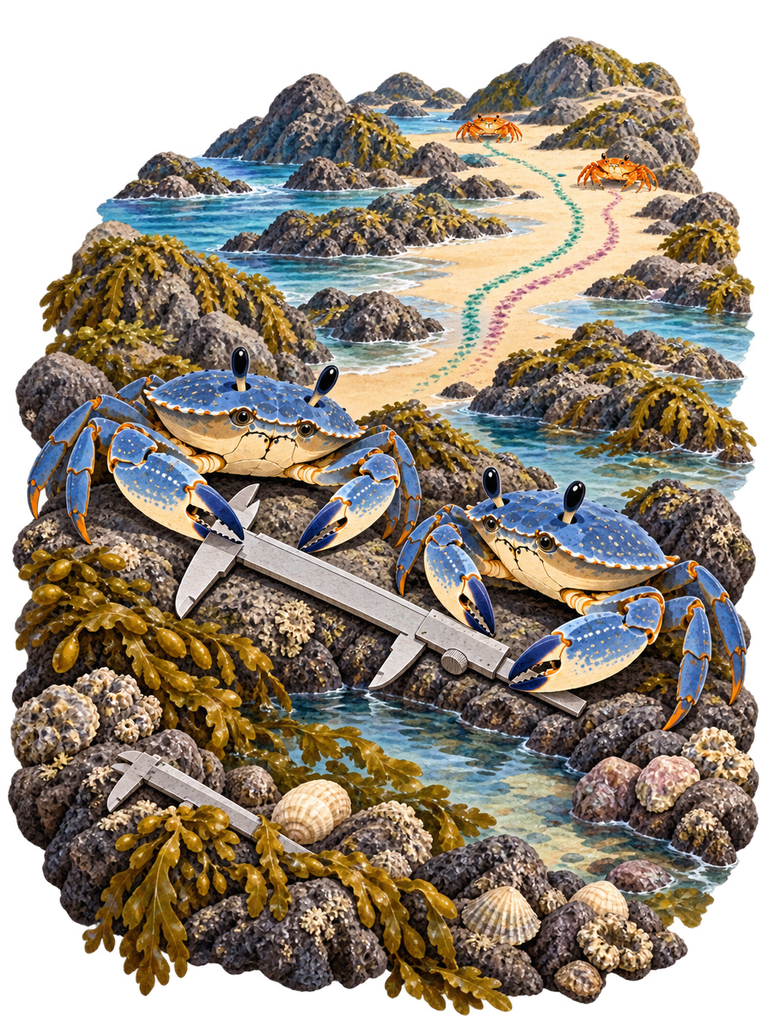

Ilustrace vytvořená pomocí AI.

## Co vlastně na krabovi měříme?

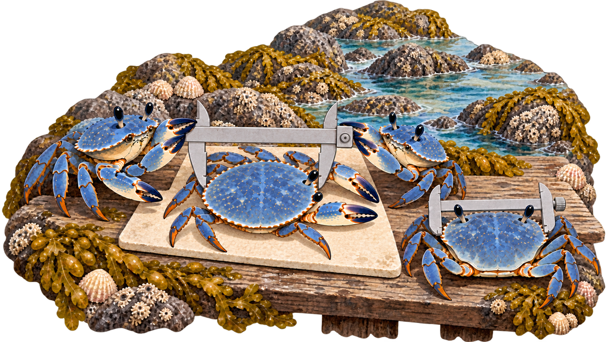

Ilustrace vytvořená pomocí AI.

**Délka krunýře** a **zadní šířka krunýře** jsou dvě měření téhož kraba.

## Co si pamatujete z minulé lekce?

Odpovězte samostatně na tři krátké otázky. Na telefonu neuvidíte odpovědi ostatních; společné výsledky otevřeme až po hlasování.

[figure not shown]

[Otevřít dotazník v novém okně](https://pollslive.com/p/l08-opakov-n-p-edchoz-lekce-2026-27-8ew3l9ve)

## Jak odpovídala skupina?

[interactive chart not shown]

[Otevřít výsledky mimo prezentaci](https://pollslive.com/p/l08-opakov-n-p-edchoz-lekce-2026-27-8ew3l9ve?view=results)

## Proč se po přidání maximální teploty změnil sklon roční teploty i jeho SE?

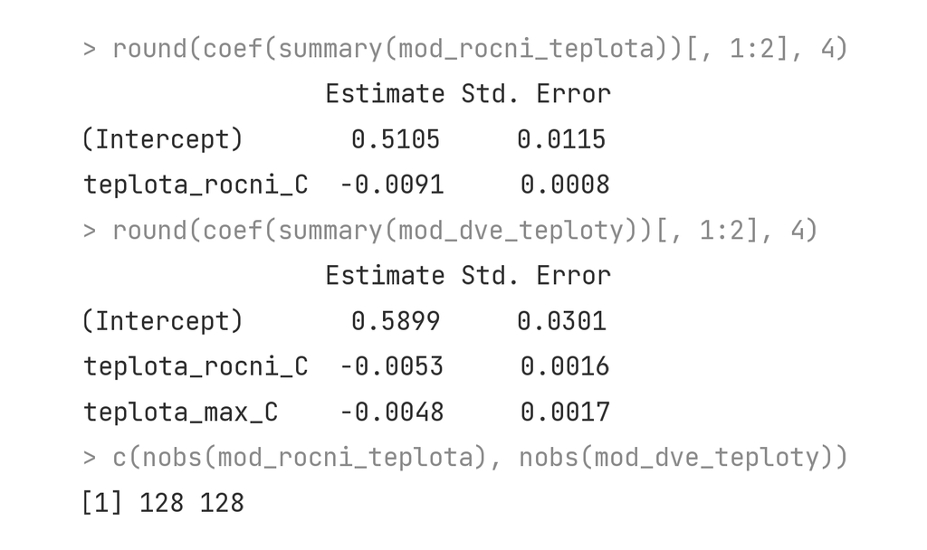

- První model byl chybný; až druhý ukazuje skutečný účinek roční teploty.
- Maximální teplota stojí ve formuli druhá, a proto převzala část efektu.
- Koeficient teď platí při stejné maximální teplotě; obě teploty silně korelují.
- Po přidání prediktoru model použil méně populací než předtím.

Správná odpověď: Koeficient teď platí při stejné maximální teplotě; obě teploty silně korelují.

Nový koeficient odpovídá na užší otázku při stejné maximální teplotě (r ≈ 0,85) a tu nese málo populací, proto SE roste. Pořadí ve formuli koeficienty nemění.

## Model tloušťky listu křídlatky jen s roční teplotou dal sklon −0,0091 mm/°C. Po přidání původu populace (původní, nebo zavlečená) vyšel sklon +0,0015 mm/°C. Proč se změnilo znaménko?

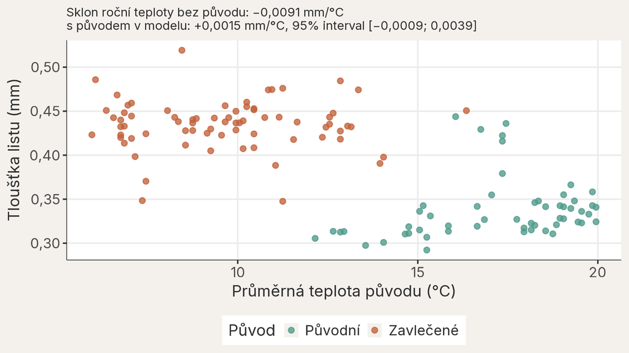

- Celkový sklon mísil rozdíl obou původů, které žijí v různě teplých oblastech.
- Roční teplota ve skutečnosti list zesiluje, první model měl opačné znaménko.
- Podmíněný sklon je statisticky nevýznamný, roční teplota tedy na list nemá vliv.
- Původ a roční teplota spolu nesouvisejí, změna je jen výběrová variabilita.

Správná odpověď: Celkový sklon mísil rozdíl obou původů, které žijí v různě teplých oblastech.

Zavlečené populace mají tlustší listy a pocházejí z chladnějších oblastí. Původ je konfundující proměnná; uvnitř původu je vztah slabý a jeho interval zahrnuje nulu.

## Chceme porovnat zavlečené a původní populace při roční teplotě 8 °C. Co platí?

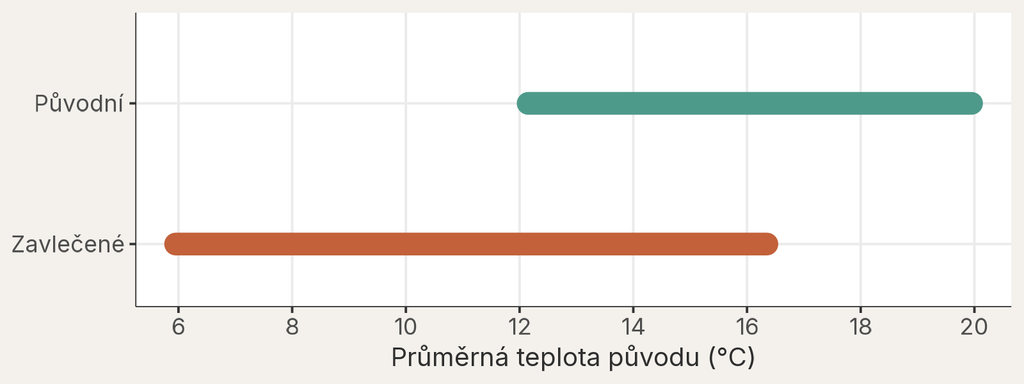

- 8 °C leží v rozsahu všech populací (6–20 °C), odhad je proto podložený.
- Původní populace pod 12 °C nemáme; rozdíl při 8 °C stojí na extrapolaci.
- Aditivní model dává stejný rozdíl při každé teplotě, takže na 8 °C nezáleží.
- Model s původem a teplotou neumí predikovat pro konkrétní teplotu.

Správná odpověď: Původní populace pod 12 °C nemáme; rozdíl při 8 °C stojí na extrapolaci.

Model rozdíl vypočte při každé teplotě, ale data ho podporují jen v překryvu obou skupin, asi 12–16 °C. Při 8 °C existují jen zavlečené populace.

## Výsledky učení

Po absolvování této přednášky budete schopni:

- rozpoznat biologickou otázku, ve které vztah jednoho prediktoru k odezvě závisí na druhém prediktoru;
- fitovat model s interakcí a zobrazit jeho predikce pro kombinace numerických i kategoriálních prediktorů;
- vyložit koeficienty modelu s interakcí jako podmíněné a porovnávat skupiny nebo různé hodnoty prediktoru pomocí predikcí;
- vysvětlit interakci dvou kategoriálních prediktorů jako rozdíl dvou rozdílů;
- omezit závěr na pozorovaný rozsah dat a na souvislost v pozorovacích datech.

# Platí rovnoběžné přímky i pro kraby?

## Proč by se samice a samci mohli lišit tvarem krunýře?

Co víme o krabech

- Zadní část krunýře leží zhruba nad zadečkem.
- Samice pod zadečkem nosí vajíčka.
- Samice a samci se liší poměrem zadní šířky a délky krunýře.

Bude rozdíl v zadní šířce mezi stejně dlouhou samicí a samcem stejný u malých i velkých krabů?

Campbell a Mahon (1974), *Australian Journal of Zoology* 22: 417–425.

## Jeden bod představuje jednoho kraba

```r
data_krabi_vse <-
  read.csv(file = "data/krabi.csv")

# sp: B = blue (modrá), O = orange (oranžová)
data_krabi <-
  data_krabi_vse[
    data_krabi_vse$sp == "B",
    c("sex", "CL", "RW")
  ]
names(data_krabi) <-
  c("pohlavi", "delka_krunyre_mm",
    "zadni_sirka_mm")
# sex: F = female (samice), M = male (samec)
data_krabi$pohlavi <-
  factor(
    x = data_krabi$pohlavi,
    levels = c("F", "M"),
    labels = c("samice", "samec")
  )
head(x = data_krabi, n = 2)
```

```
  pohlavi delka_krunyre_mm zadni_sirka_mm
1   samec             16.1            6.7
2   samec             18.1            7.7
```

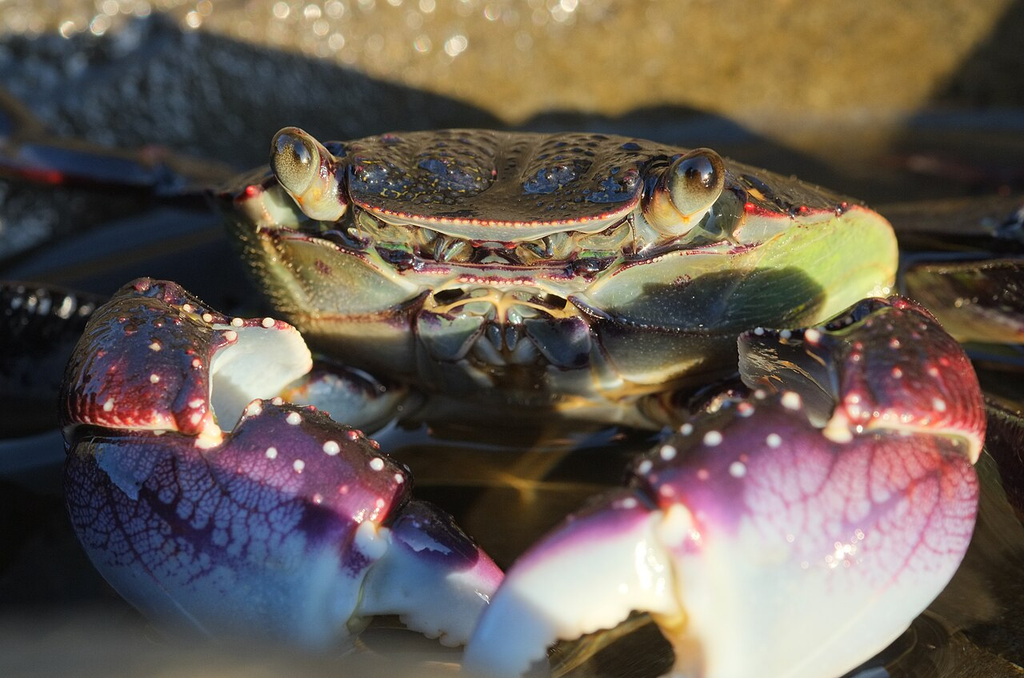

100 krabů

- 🔵 modrá barevná forma

[figure not shown]

- 50 samic ·

[figure not shown]

  50 samců
- chybějící hodnoty: 0

Campbell a Mahon (1974) · ilustrativní snímek druhu: Pseudopanax, Wikimedia Commons, volné dílo

## Co naznačují měření krabů?

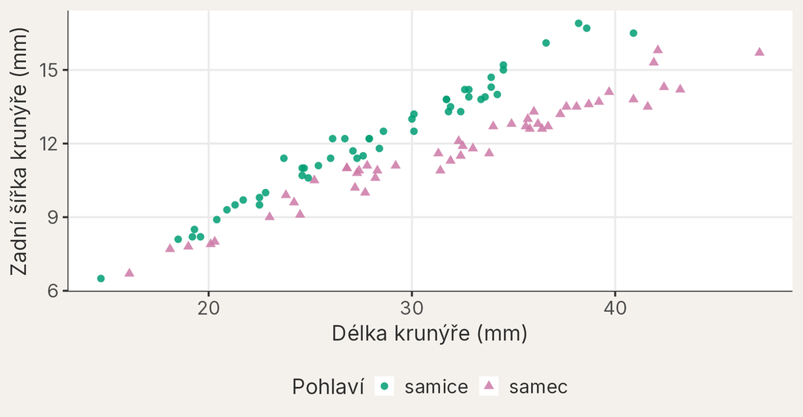

1. Jaký je směr vztahu?
2. Kde se skupiny překrývají?
3. Vypadají oba sklony stejně?

## Aditivní model kreslí rovnoběžné přímky

```r
mod_rovnobezne <-
  lm(
    formula = zadni_sirka_mm ~ delka_krunyre_mm + pohlavi,
    data = data_krabi
  )
```

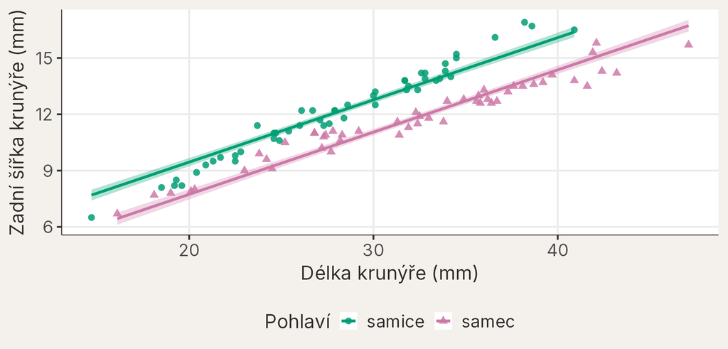

`+`: posun mezi skupinami, společný sklon · kolem přímek 95% pás spolehlivosti

## Zůstává rozdíl mezi pohlavími při každé délce stejný?

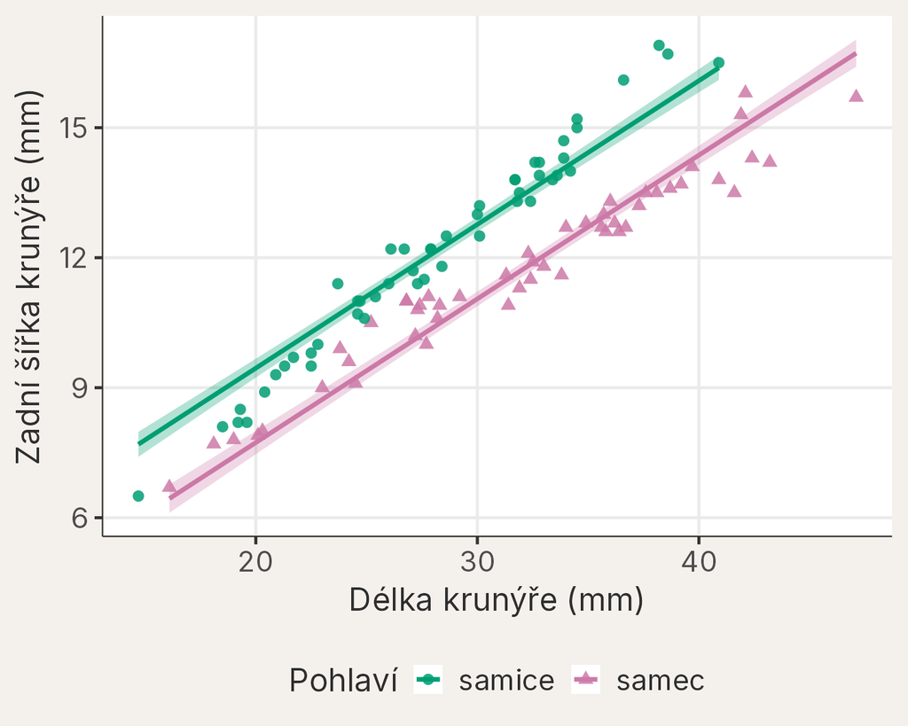

Ve dvojici

Model kreslí přímky vždy rovnoběžné.

Co o rozdílu mezi pohlavími říkají samotné body?

## Data naznačují různé sklony

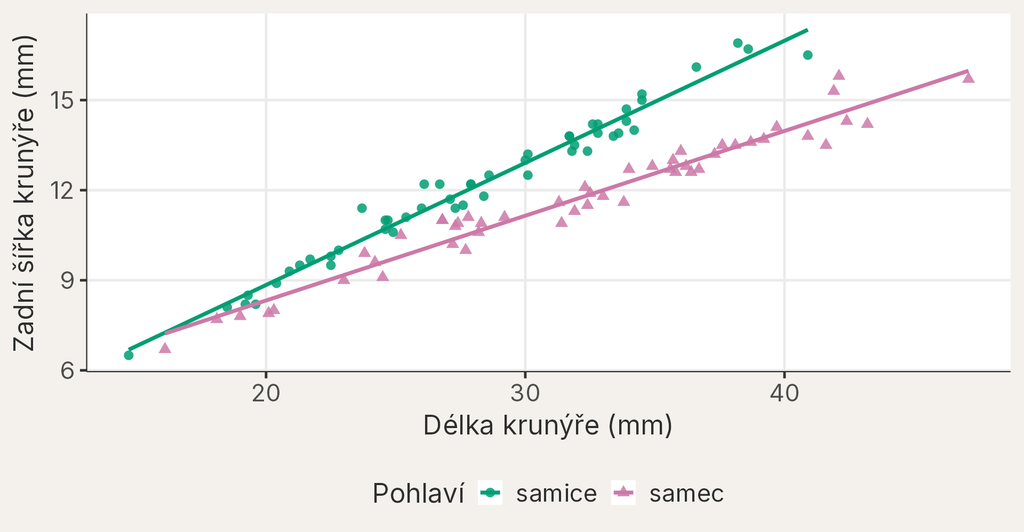

Svislá vzdálenost mezi přímkami se s délkou mění.

## Když se rozdíl mění, mluvíme o interakci

[figure not shown]

**Aditivní model**

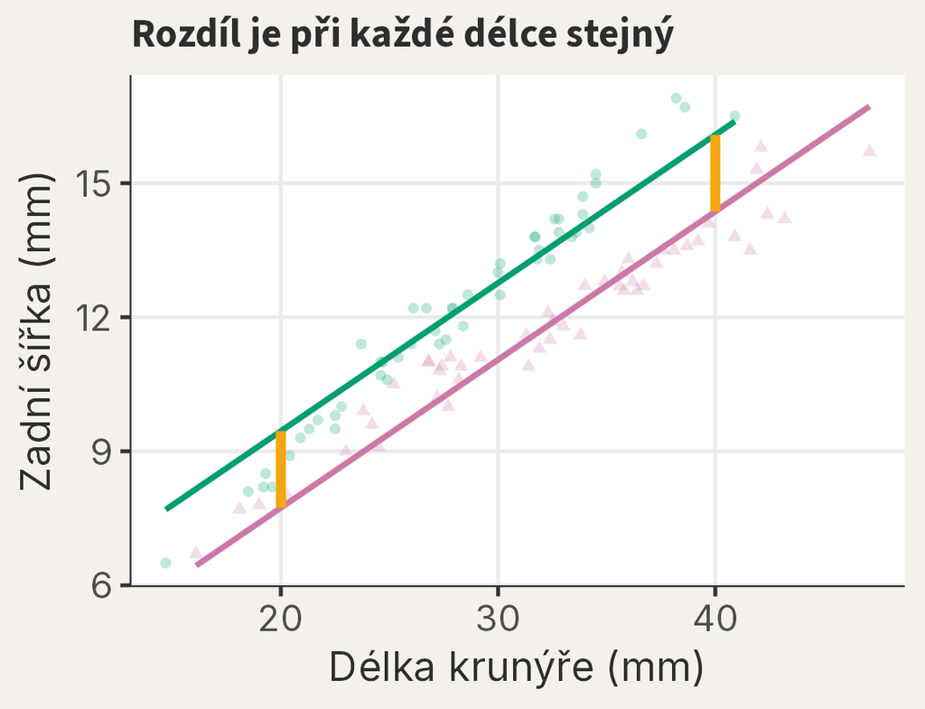

[figure not shown]

**Model s interakcí**

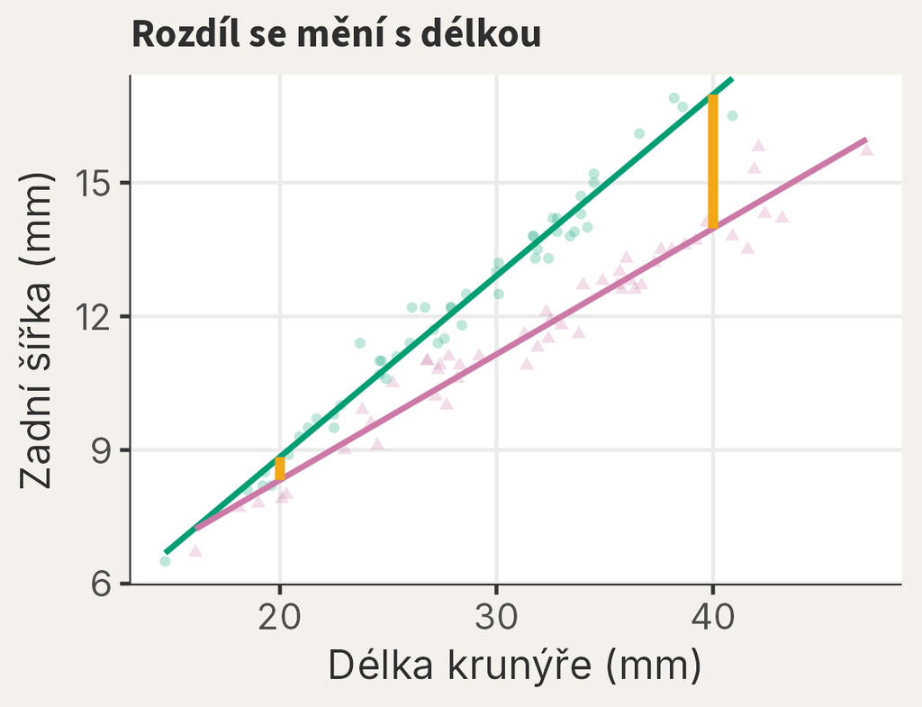

**Interakce:** vztah délky a zadní šířky závisí na pohlaví.

## Jak zapsat model s interakcí?

[figure not shown]

1. `zadni_sirka_mm ~ delka_krunyre_mm + pohlavi`

[figure not shown]

2. `zadni_sirka_mm ~ delka_krunyre_mm + pohlavi`  
   `+ delka_krunyre_mm:pohlavi`

[figure not shown]

3. `zadni_sirka_mm ~ delka_krunyre_mm * pohlavi`

`x * y` je zkratka pro `x + y + x:y`: **hlavní efekty** `x` a `y` a **interakční člen** `x:y`.

## Model s interakcí dovoluje dvěma pohlavím různé sklony

```r
# Pozor na hvězdičku: * místo + dovolí různé sklony
mod_interakce <-
  lm(
    formula = zadni_sirka_mm ~ delka_krunyre_mm * pohlavi,
    data = data_krabi
  )
```

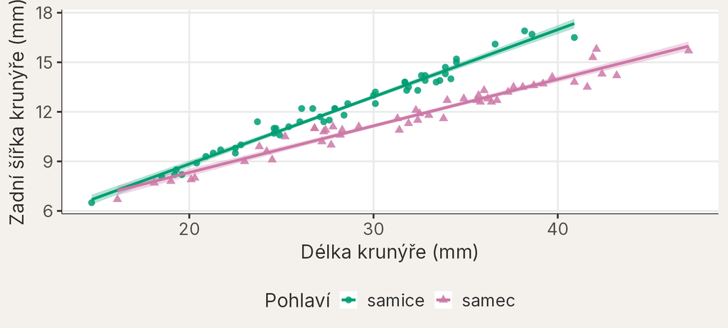

95% pás spolehlivosti jako v předchozích lekcích · každá přímka jen přes délky své skupiny

## Jakou zadní šířku model predikuje pro dva stejně dlouhé kraby?

```r
# Společná délka uvnitř rozsahu obou pohlaví
delka_porovnani_mm <- 30
```

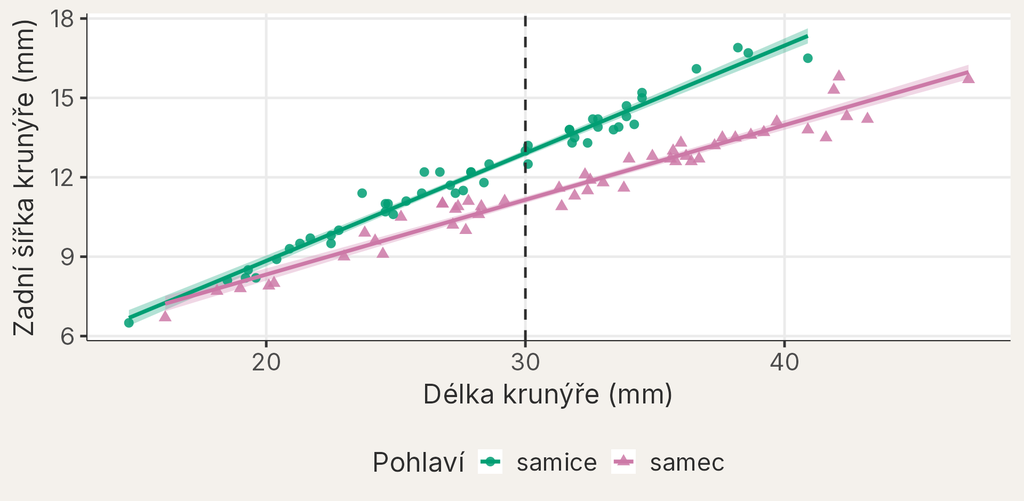

Která přímka je při 30 mm výše? O kolik přibližně?

## Dvě predikce při stejné délce krunýře

```r
# Dva modeloví krabi: stejná
#   délka, různé pohlaví
data_porovnani <-
  data.frame(
    delka_krunyre_mm = rep(
      x = delka_porovnani_mm,
      times = 2
    ),
    pohlavi = c("samice", "samec")
  )

data_porovnani$predikce_sirky_mm <-
  predict(
    object = mod_interakce,
    newdata = data_porovnani
  )
```

```r
data_porovnani
```

```
  delka_krunyre_mm pohlavi predikce_sirky_mm
1               30  samice          12.91000
2               30   samec          11.14947
```

[figure not shown]

řádek 1: samice

[figure not shown]

řádek 2: samec

## Samec má při 30 mm užší zadní část krunýře

[figure not shown]

**Samice**

12,91 mm

[figure not shown]

**Samec**

11,15 mm

**Samec − samice**

−1,76 mm

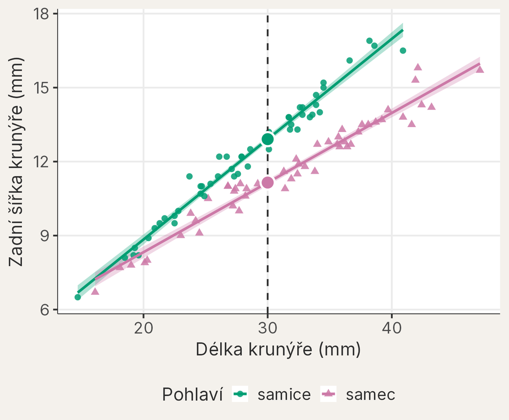

## Co už můžeme říci o stejně dlouhých krabech?

Co víme

- Zadní šířka roste s délkou u obou pohlaví.
- Samčí přímka stoupá pomaleji.
- Při 30 mm má samec zadní šířku o 1,76 mm menší.

Co ještě nevíme

- Jak tento výsledek vyjadřují koeficienty modelu?
- Jak přesně známe rozdíl sklonů?

## Rozdíl mezi pohlavími se s délkou mění

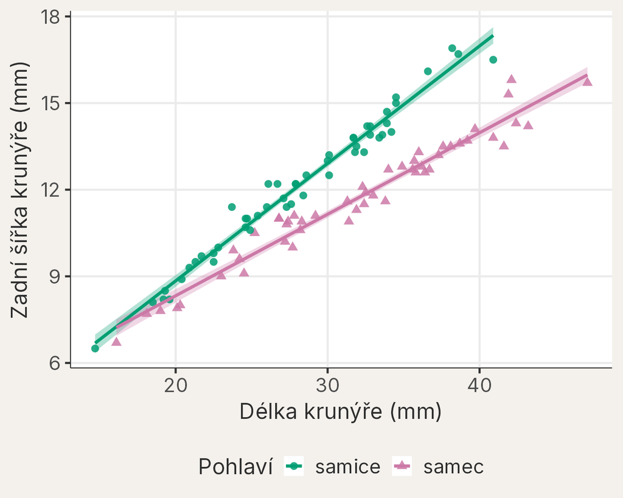

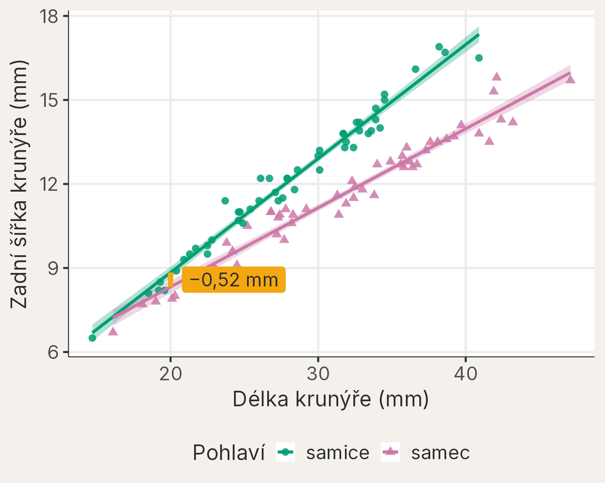

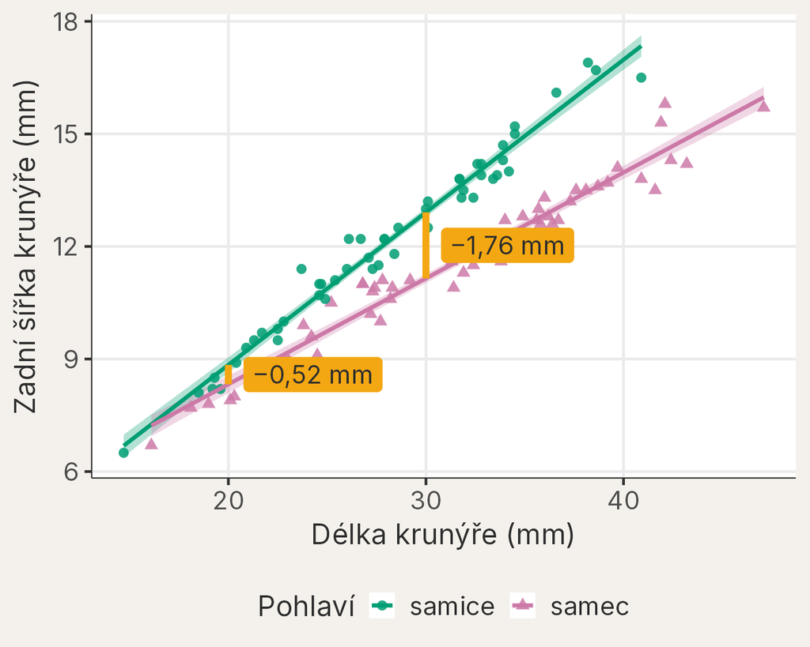

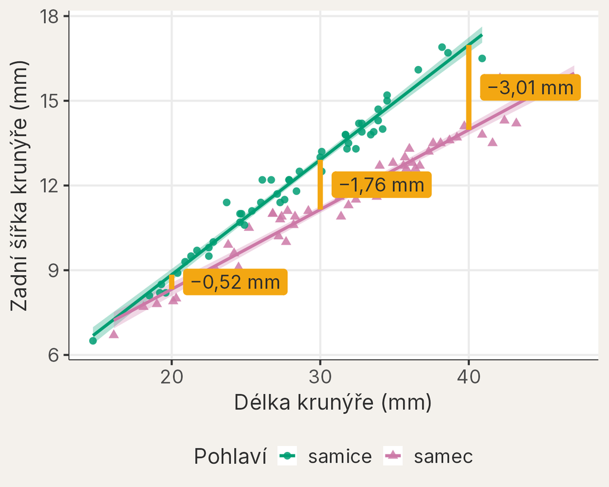

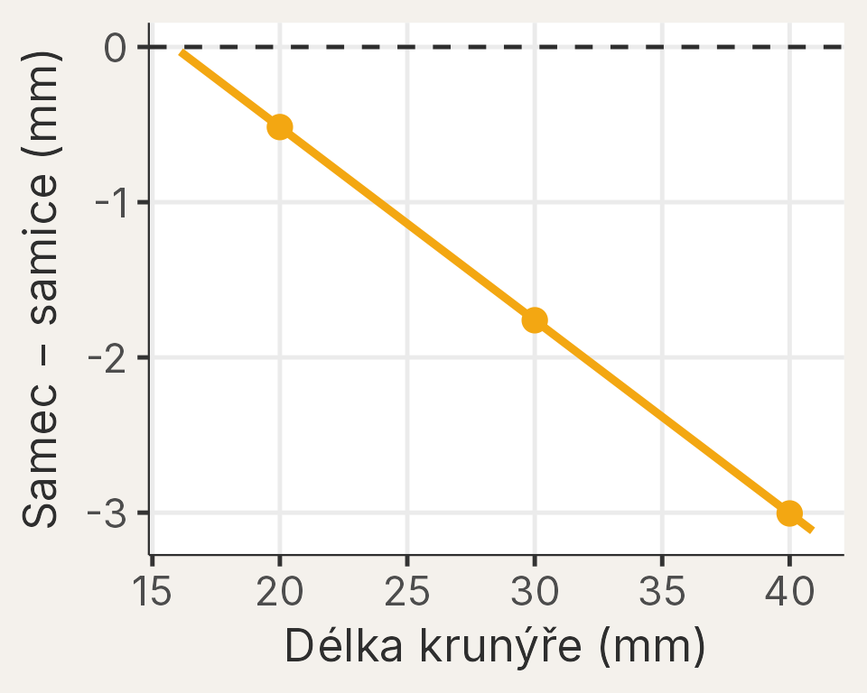

Ve dvojici

Proč tu model s interakcí popisuje data lépe než aditivní model?

# Koeficienty interakčního modelu

## Jaké jsou koeficienty v `summary()`?

```r
souhrn_interakce <-
  summary(object = mod_interakce)

round(
  x = souhrn_interakce$coefficients,
  digits = 3
)
```

```
                              Estimate Std. Error t value Pr(>|t|)
(Intercept)                      0.708      0.294   2.409    0.018
delka_krunyre_mm                 0.407      0.010  39.742    0.000
pohlavisamec                     1.973      0.400   4.928    0.000
delka_krunyre_mm:pohlavisamec   -0.124      0.013  -9.450    0.000
```

Estimate

Odhad koeficientu: číslo, které vykládáme.

Std. Error

Standardní chyba (SE): přesnost odhadu a základ intervalu spolehlivosti.

## První dva koeficienty popisují referenční samice

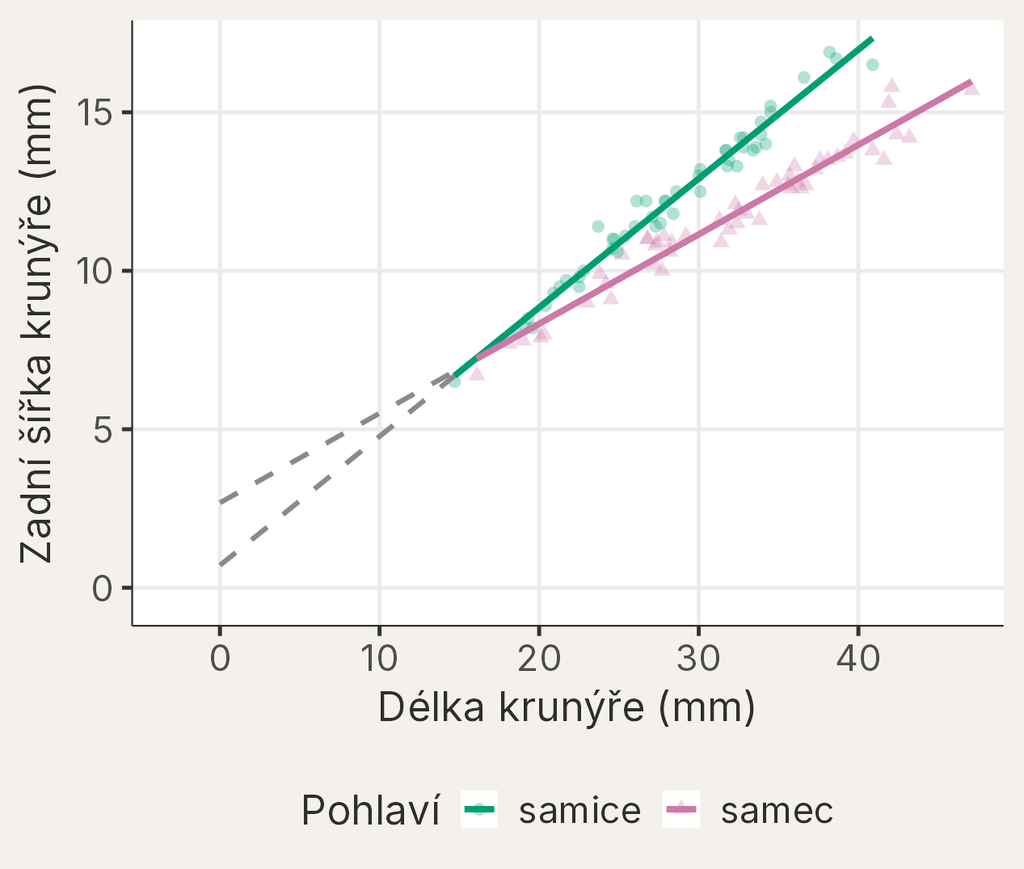

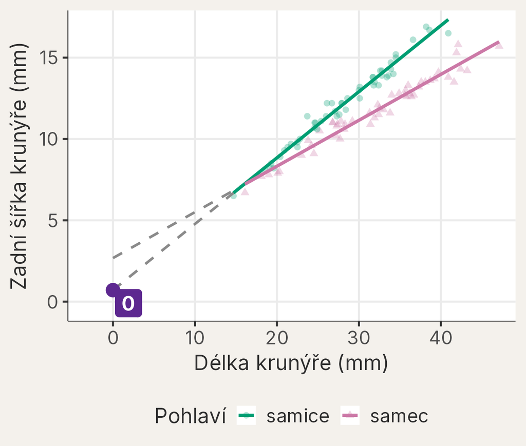

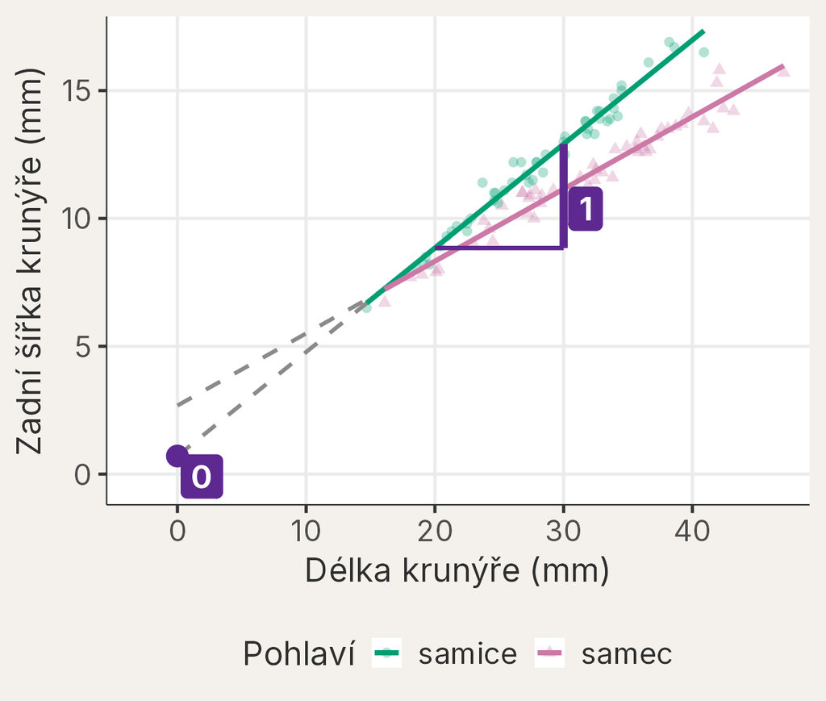

Číslo značky = index $\hat\beta$ v pořadí řádků výpisu `summary()`.

0 · $\hat\beta_0$ `(Intercept)`

0,708 mm

Výška samičí přímky při délce **0 mm**: hypotetický krab mimo data.

1 · $\hat\beta_1$ `delka_krunyre_mm`

+0,407 mm/mm

Sklon samičí přímky: o 10 mm delší samice má odhadem o 4,07 mm širší zadní část.

## Koeficient pohlaví porovnává skupiny při délce 0 mm

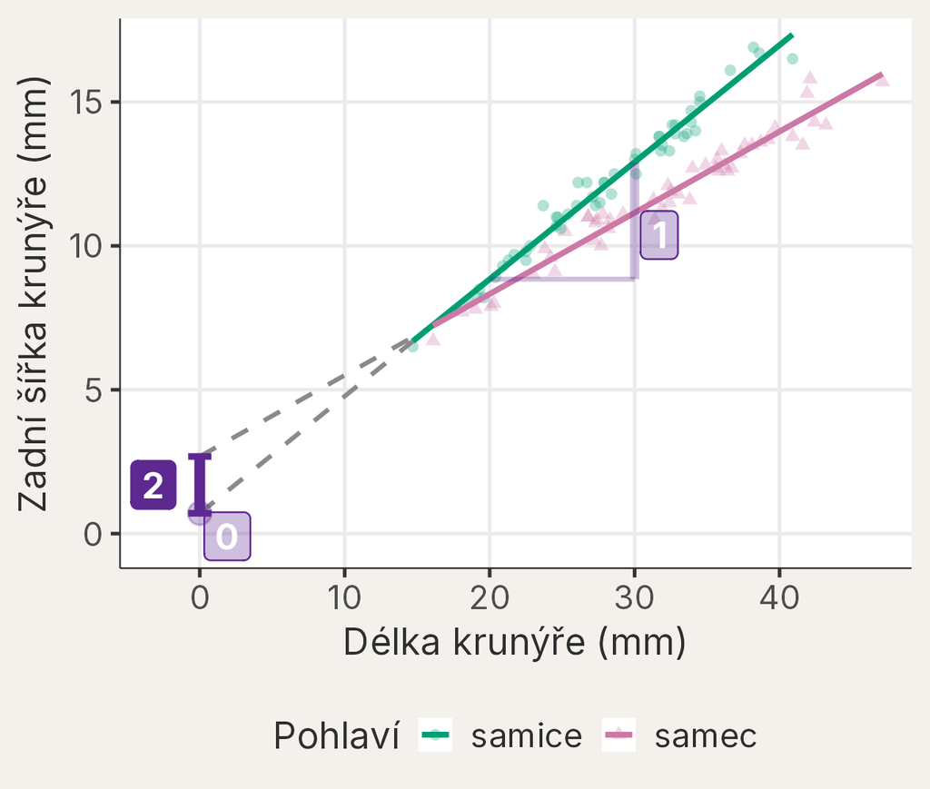

Číslo značky = index $\hat\beta$ v pořadí řádků výpisu `summary()`.

2 · $\hat\beta_2$ `pohlavisamec`

+1,973 mm

Rozdíl **samec − samice**, když `delka_krunyre_mm = 0`.

## Platí koeficient `pohlavisamec` při každé délce?

**A)** Ano, při každé délce.

**B)** Ne, pouze při délce 0 mm.

**C)** Ne, pouze při délce 30 mm.

`pohlavisamec` není:

- rozdíl při každé délce;
- rozdíl při 30 mm;
- průměrný rozdíl mezi všemi samci a samicemi.

**Biologicky smysluplné srovnání získáme z predikcí uvnitř dat.**

## Interakční koeficient mění sklon samců vůči samicím

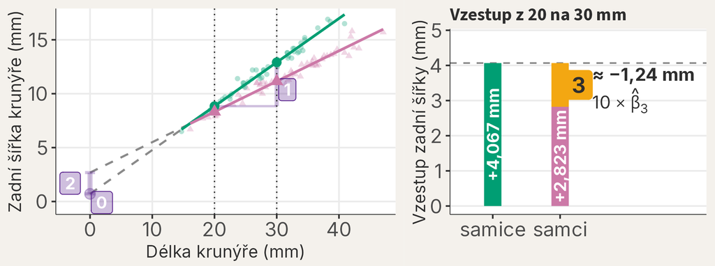

3 · $\hat\beta_3$ `delka_krunyre_mm:pohlavisamec`

−0,1245 mm/mm: **interakční koeficient**, o kolik je sklon samců jiný než sklon samic.

$$\begin{aligned}
\text{sklon samců}
&=
\text{0,4067}
+
(\text{−0,1245}) \\
&\approx
\text{0,282}\ \text{mm/mm}
\end{aligned}$$

SE = 0,013; 95% interval spolehlivosti −0,151 až −0,098 mm/mm

## Rozdíl při 30 mm skládají dva známé příspěvky

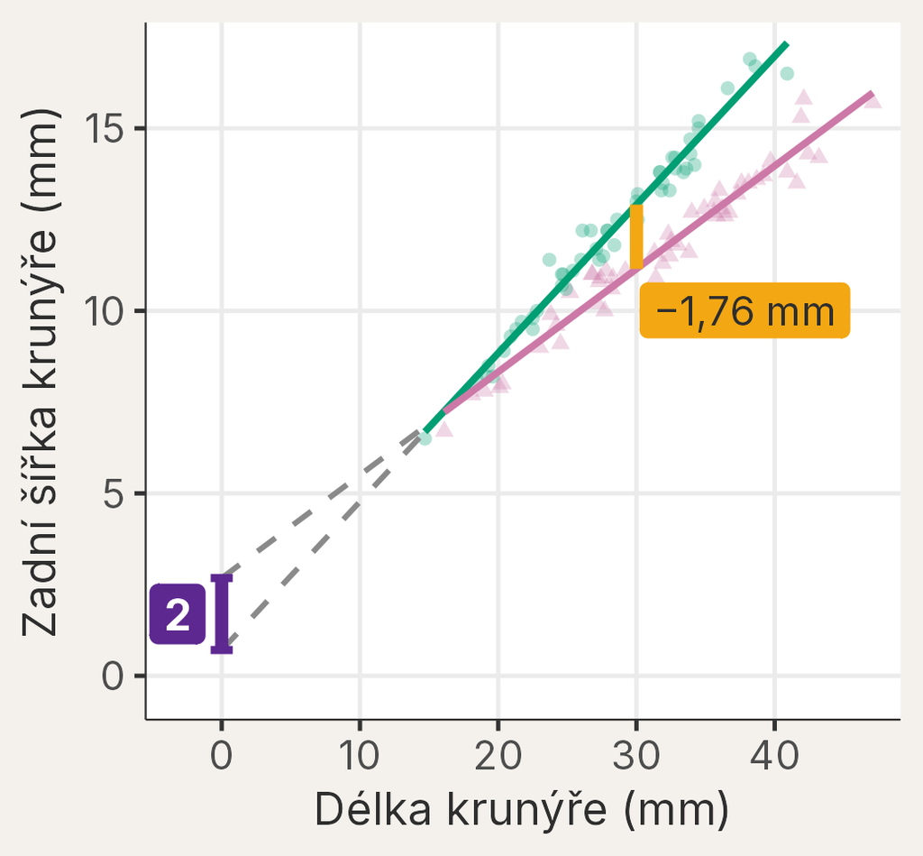

Číslo značky = index: $\hat\beta_0$ až $\hat\beta_3$ jsou řádky výpisu `summary()` shora dolů.

Samice: $\hat y = {\color{#5D2890}{\hat\beta_0}} + {\color{#5D2890}{\hat\beta_1}}\,x$

Samci: $\hat y = ({\color{#5D2890}{\hat\beta_0}} + {\color{#5D2890}{\hat\beta_2}}) + ({\color{#5D2890}{\hat\beta_1}} + \bbox[#F3A712,2pt]{\hat\beta_3})\,x$

Rozdíl samec − samice: $\text{rozdíl}(x) = {\color{#5D2890}{\hat\beta_2}} + \bbox[#F3A712,2pt]{\hat\beta_3}\,x$

$$\begin{aligned}
\text{rozdíl}(30)
&=
\text{1,973}
+ 30 \times (\text{−0,1245}) \\
&\approx
\mathbf{\text{−1,76}\ \text{mm}}
\end{aligned}$$

Je to stejný rozdíl, který jsme odečetli z predikcí.

## Jak dobře přímky popisují změřené kraby?

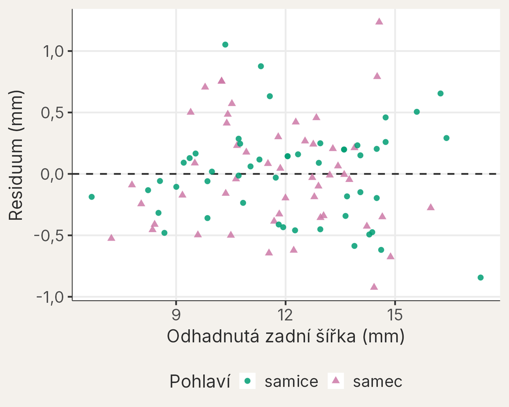

Residua leží kolem nuly bez oblouku (nelinearity) a s konstantním rozptylem residuí u malých i velkých krabů.

Graf neověří příčinu ani platnost mimo pozorované délky.

## Sedí model s interakcí k datům i v dalších grafech?

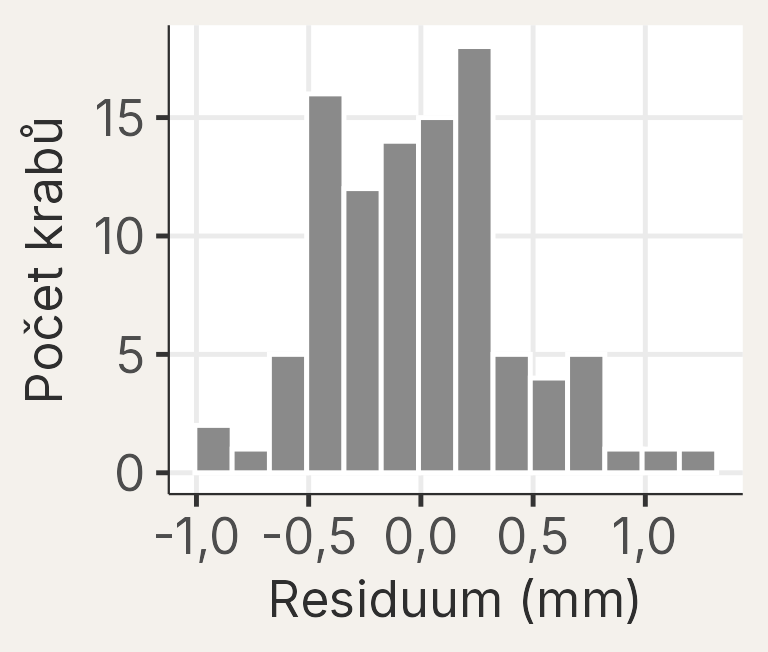

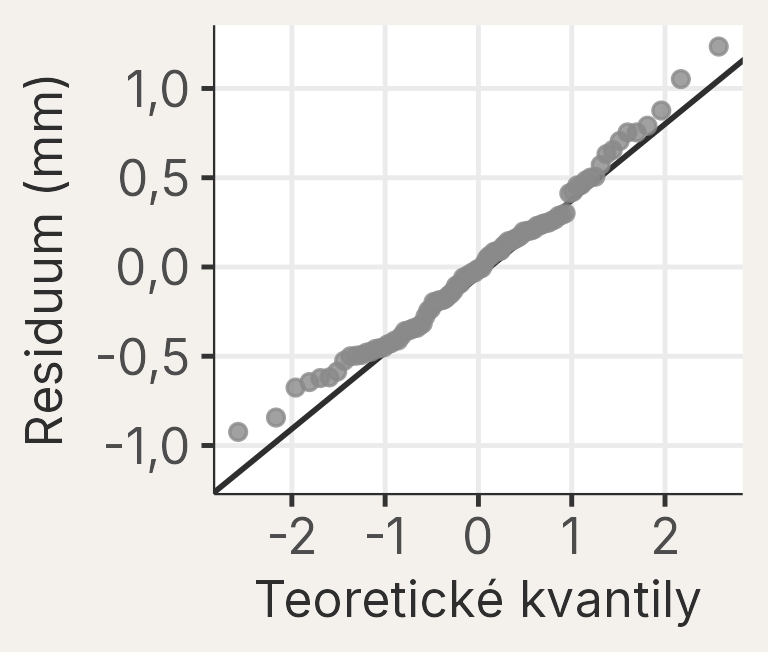

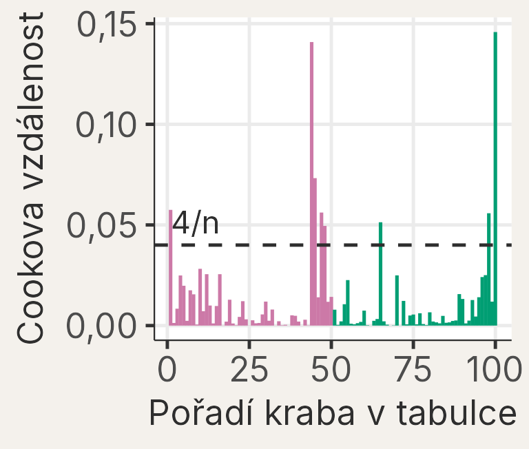

[figure not shown]

samice ·

[figure not shown]

samec

Stejné grafy jako v minulých lekcích: je na některém z nich něco znepokojivého?

## Co víme o rozdílu mezi samicemi a samci modré formy?

Bude rozdíl v zadní šířce mezi stejně dlouhou samicí a samcem stejný u malých i velkých krabů?

Co data ukazují

- Sklon samic 0,407, samců 0,282 mm/mm.
- Rozdíl samec − samice se mění o −0,124 mm na 1 mm délky (SE 0,013; 95% interval spolehlivosti −0,151 až −0,098).
- Při 30 mm: samec − samice −1,76 mm.

Co zůstává otevřené

- Proč se pohlaví liší: data jsou pozorovací.
- Platí to i pro kraby mimo tento výběr?
- A pro kraby menší nebo větší, než jsme změřili?

Každý krab je v datech jednou; nezávislost plyne ze způsobu sběru, ne z grafu.

# Když jsou oba prediktory skupiny

## Liší se rozdíl mezi pohlavími u modré a oranžové formy?

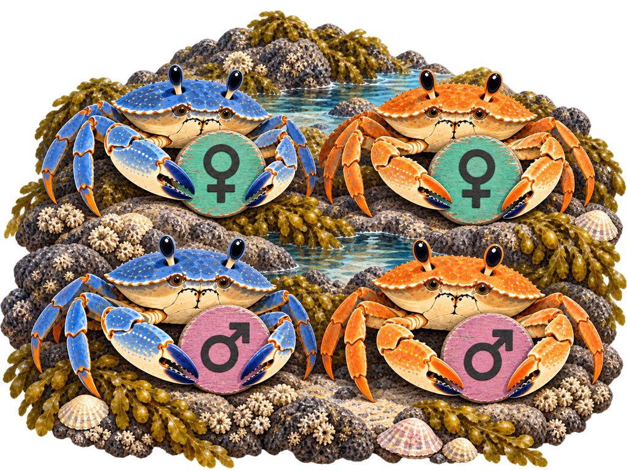

Ilustrace vytvořená pomocí AI.

Odezva

Délka krunýře (mm)

Dva kategoriální prediktory

Barevná forma · pohlaví

Mění se rozdíl **samec − samice** mezi barevnými formami?

Do každé skupiny vybrali autoři stejný počet krabů, takže průměrné délky závisejí i na výběru.

## Jaké délky vidíme ve čtyřech skupinách?

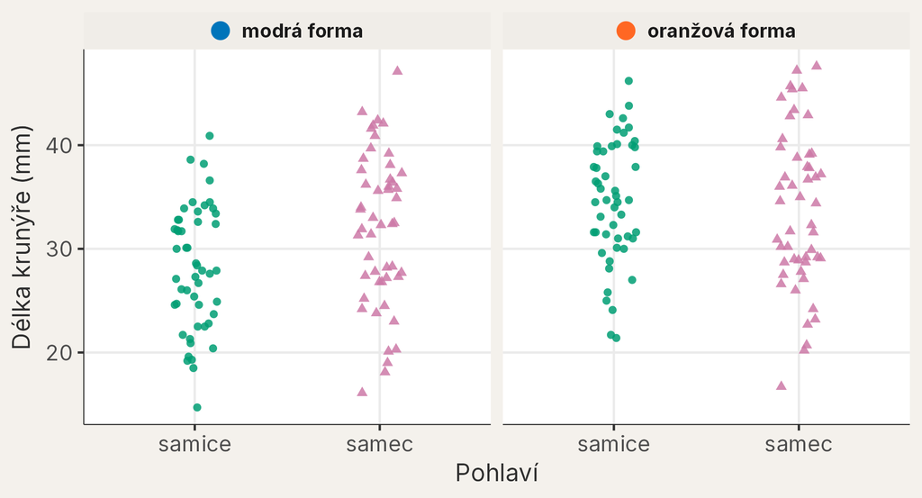

Každý bod je jeden krab. Autoři vybrali do každé skupiny 50 krabů.